# Partial and Semi-Partial Correlations Key

Daniel Anderson

Due: November 13, 2018

# Content Knowledge

1. Name and describe what each of the following figures are showing.

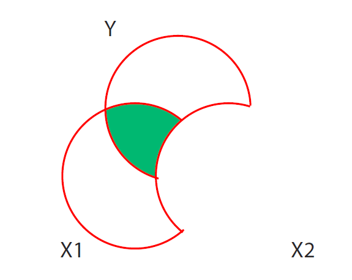

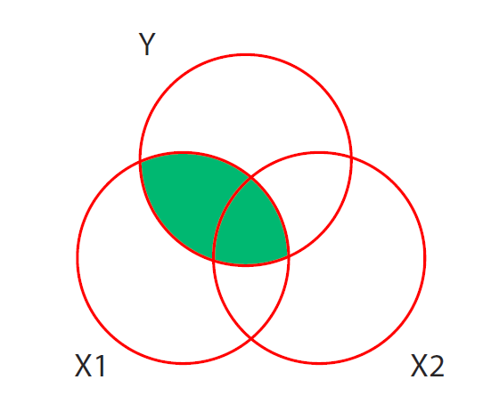

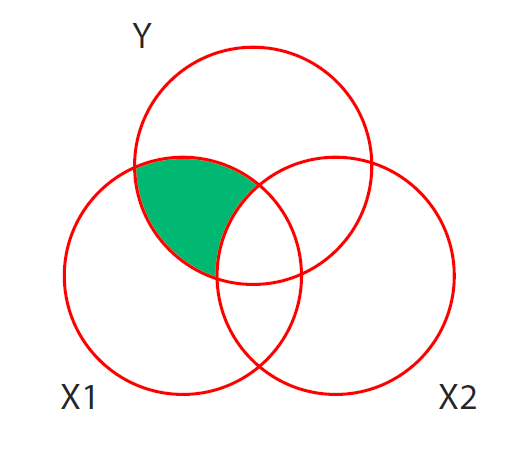

- The first diagram shows a partial correlation squared, also known as partial $\eta^2$. It shows the relation between X1 and Y, with both variables residualized with respect to X2.
- The second diagram shows the zero-order correlation between X1 and Y, squared. This is the variance accounted for in Y without including any other variables.
- The third diagram shows the squared semi-partial correlation between X1 and Y. It shows the relation between X1 and Y, with X1 residualized with respect to X2.
2. Briefly (1-2 sentences) describe the difference between partial and semi-partial correlations.

Partial correlations are the unique relation between a variable and the residualized outcome, while semi-partial correlations are the unique relation between a variable and the outcome. In other words, for both correlations the X variable is residualized with respect to all other variables in the model, but for partial correlations the outcome is also residualized.

3. Briefly (3 sentences max) describe which type of correlation is generally more useful, and why.

Semi-Partial correlations are generally more useful because the denominator is always the same, making them all directly comparable. Further, if the values are squared, they are on the same scale as the model $R^2$ and can be interpreted as the unique variance accounted for by the predictor variable, controlling for all other variables in the model.

# Applied Practice

1. Use the code chunk below to import the “depression.xlsx” dataset

```r
library(tidyverse)
library(rio)
library(here)
theme_set(theme_minimal())

d <- import(here("data", "depression.xlsx"),
            setclass = "tbl_df")
```

In the code chunk below, fit a model that addersses the following research questions.

> RQ1: What is the effect of income and physical health on depression, controlling for age and marital status?

In the data, `depression_score` indicates the overall depressive symptoms the individual is exhibiting, with higher values indicating greater depression. Because health and marital status are categorical, they will need to have a reference group defined. Define these variables such that the reference group represents individuals who were married and in poor health. Note that after fitting the model you will still need to interpret the intercept relative to **all** variables in the model

```r
d <- d %>%
  mutate(health = factor(health),
         health = relevel(health, ref = "poor"),
         marital  = factor(marital),
         marital  = relevel(marital, ref = "married"))
m <- lm(depression_score ~ health + income + age + marital, d)
summary(m)
```

```
##
## Call:
## lm(formula = depression_score ~ health + income + age + marital,
##     data = d)
##
## Residuals:
##     Min      1Q  Median      3Q     Max
## -13.638  -5.291  -2.516   3.171  34.228
##
## Coefficients:
##                      Estimate Std. Error t value Pr(>|t|)
## (Intercept)          21.92180    3.12310   7.019 1.64e-11 ***
## healthexcellent      -7.72720    2.41414  -3.201 0.001526 **
## healthfair           -0.91192    2.65434  -0.344 0.731434
## healthgood           -6.38200    2.39411  -2.666 0.008122 **
## income               -0.08589    0.03496  -2.457 0.014598 *
## age                  -0.12590    0.03581  -3.516 0.000509 ***
## maritaldivorced       0.32014    1.49273   0.214 0.830339
## maritalnever married  0.48990    1.38332   0.354 0.723488
## maritalseparated      3.37484    2.47620   1.363 0.173990
## maritalwidowed        0.19831    1.79637   0.110 0.912173
## ---
## Signif. codes:  0 '***' 0.001 '**' 0.01 '*' 0.05 '.' 0.1 ' ' 1
##
## Residual standard error: 8.284 on 284 degrees of freedom
## Multiple R-squared:  0.1456, Adjusted R-squared:  0.1185
## F-statistic: 5.377 on 9 and 284 DF,  p-value: 8.372e-07
```

2. Calculate squared semi-partial correlations for the model in the code chunk below.

```r
library(lmSupport)
modelEffectSizes(m)
```

```
## lm(formula = depression_score ~ health + income + age + marital,
##     data = d)
##
## Coefficients
##                   SSR df pEta-sqr dR-sqr
## (Intercept) 3381.3654  1   0.1478     NA
## health      1627.1787  3   0.0771 0.0713
## income       414.3980  1   0.0208 0.0182
## age          848.5054  1   0.0417 0.0372
## marital      128.6126  4   0.0066 0.0056
##
## Sum of squared errors (SSE): 19490.8
## Sum of squared total  (SST): 22812.1
```

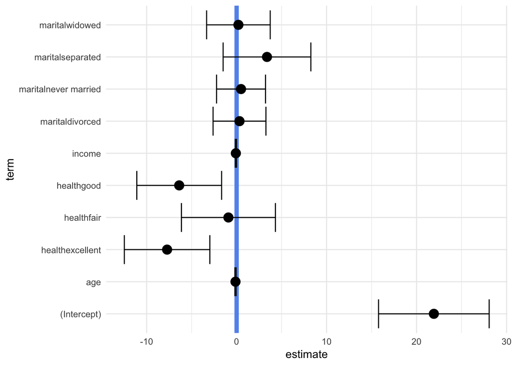

```r
library(broom)
tidy_pd <- tidy(m, conf.int = TRUE)

ggplot(tidy_pd, aes(term, estimate)) +
  geom_hline(yintercept = 0,
             color = "cornflowerblue",
             size = 2) +
  geom_point(size = 4) +
  geom_errorbar(aes(ymin = conf.low,
                    ymax = conf.high)) +
  coord_flip()
```

4. In a word document provide a table of the model, and a brief interpretation of the findings. Write as if you were writing the results up for publication. Include confidence intervals in your table and reference the squared semipartial correlations in text.